# Medal counts by countries

Let's load a dataset stored in a file names "Olympic_medals_2016.csv".

The dataset counts the total number of medals won by 10 countries, which have the most medals in the 2016 Summer Olympics Games in Rio. The 'NOC' column includes the abbrevation of the countries.

Note that we will need to import the pandas library first.

```python
import pandas as pd

medals_2016 = pd.read_csv("Data/Olympic_medals_2016.csv")
medals_2016
```

|  | Year | NOC | Medal |
| --- | --- | --- | --- |
| 0 | 2016 | AUS | 29 |
| 1 | 2016 | CAN | 22 |
| 2 | 2016 | CHN | 70 |
| 3 | 2016 | FRA | 42 |
| 4 | 2016 | GBR | 67 |
| 5 | 2016 | GER | 42 |
| 6 | 2016 | ITA | 28 |
| 7 | 2016 | JPN | 41 |
| 8 | 2016 | RUS | 56 |
| 9 | 2016 | USA | 121 |

Which chart should we use to visualize the medal counts by countries?

# Bar Charts in matplotlib

The `bar()` function in `matplotlib.pyplot` helps us create bar charts. It has two mandatory arguments, the indexes and the values.

- The indexes specify the categories to be placed on the x-axis
- The values specifiy the height of each bar.

The basic command is:

- `plt.bar(indexes, values)`
- `plt.show()`

A simple example:

- Suppose that in a group of programmers:
  - 10 people prefers C++ as a programming language
  - 15 prefers Python
  - 5 prefers Java

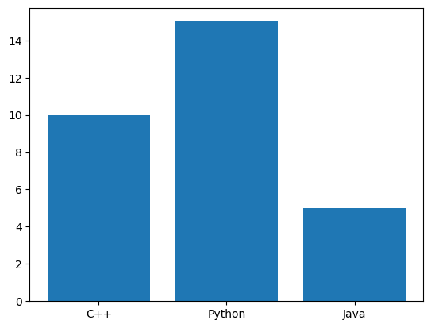

```python
import matplotlib.pyplot as plt
plt.bar(['C++', 'Python', 'Java'], [10, 15, 5])
plt.show()
```

## Medal counts by countries -- Single bar chart

Now we will create a bar chart to visualize the top 10 countries with the most medals.

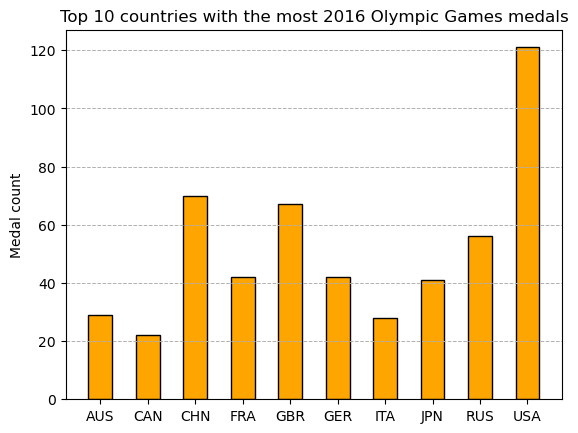

```python
plt.bar(medals_2016['NOC'],medals_2016['Medal'],width=0.5, color='orange',edgecolor='black')
plt.ylabel('Medal count')
plt.title('Top 10 countries with the most 2016 Olympic Games medals')
plt.grid(linestyle='--',linewidth=0.7,axis='y')
plt.show()
```

We may use optional arguments in the bar() function to customize our bar graph.

For additional options please see [matplotlib.pyplot.bar — documentation](https://matplotlib.org/stable/api/_as_gen/matplotlib.pyplot.bar.html).

To create a **horizontal** bar chart, replace `bar()` with `barh()`

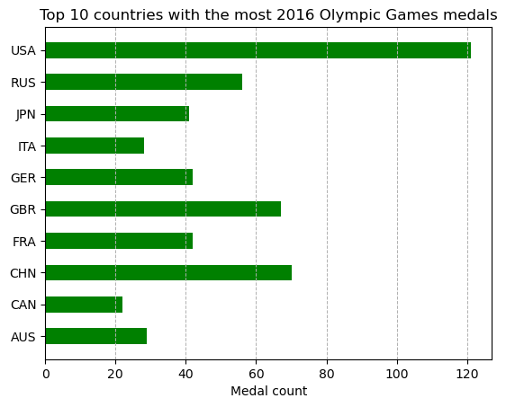

```python
plt.barh(medals_2016['NOC'],medals_2016['Medal'], color='green',height=0.5)
plt.xlabel('Medal count')
plt.title('Top 10 countries with the most 2016 Olympic Games medals')
plt.grid(linestyle='--',linewidth=0.7,axis='x')
plt.show()
```

What if we want to visualize the number of medals for multiple years?

## Stacked bar chart

Let us look at two years, 2012 and 2016.

Let's load the data for 2012.

```python
medals_2012 = pd.read_csv("Data/Olympic_medals_2012.csv")
medals_2012
```

|  | Year | NOC | Medal |
| --- | --- | --- | --- |
| 0 | 2012 | AUS | 35 |
| 1 | 2012 | CAN | 18 |
| 2 | 2012 | CHN | 88 |
| 3 | 2012 | FRA | 35 |
| 4 | 2012 | GBR | 65 |
| 5 | 2012 | GER | 44 |
| 6 | 2012 | ITA | 28 |
| 7 | 2012 | JPN | 38 |
| 8 | 2012 | RUS | 82 |
| 9 | 2012 | USA | 103 |

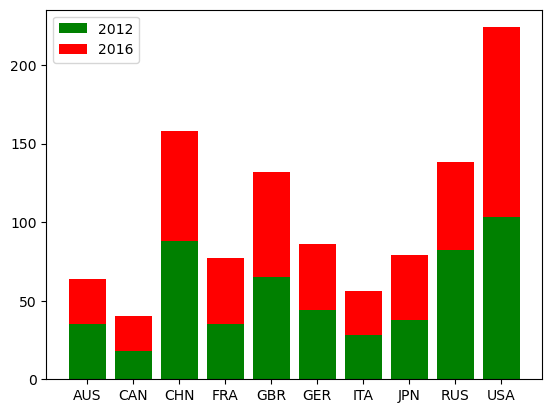

```python
plt.bar(medals_2012['NOC'],medals_2012['Medal'],color='green',label='2012')
plt.bar(medals_2016['NOC'],medals_2016['Medal'],color='red',bottom=medals_2012['Medal'],label='2016')
plt.legend()
plt.show()
```

Again, we may add a title, axis labels, grid, etc

## Side-by-side chart

To make side-by-side bar charts, it is important that all the series share the same categories. However, the placement of the bars on the x-axis should not be the same (otherwise we should use the stacked bar).

Given that we have 10 countries, let us create a numpy array for the positions of the bars.

```python
import numpy as np
positions = np.arange(10)
positions
```

```
array([0, 1, 2, 3, 4, 5, 6, 7, 8, 9])
```

For 2012, we will plot the bars at the positions $x=0,1,...,9$

For 2016, we will plot the bars at $x=0.4,1.4,...,9.4$

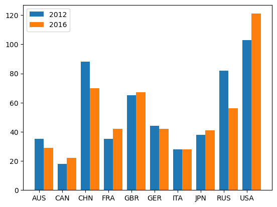

```python
plt.bar(positions,medals_2012['Medal'],width=0.4,label='2012')
plt.bar(positions+0.4,medals_2016['Medal'],width=0.4,label='2016')
plt.legend()
plt.xticks(positions,medals_2012['NOC'])
plt.show()
```